# Quarto Slides Cheat Sheet

clean-revealjs formatting reference

Dr. Sarah Dreier

University of New Mexico

## About this cheat sheet

A browsable reference for formatting slides in this deck style (`format: clean-revealjs`). To actually **start a new deck**, duplicate `sarah_slide_template.qmd` instead — this file is for looking things up, not for building on top of.

**Every deck opens with two blank slides, in this order** (Reading Prompt, then Announcements — see below; no “Wrap up from last class” slide) **and ends with a TL;DR slide, then a References slide** (see the last slides in this file) with 3–5 real takeaways generated from that lecture’s actual content.

## Reading Prompt

## Announcements

## Pausing between lines or images

**The simplest way — three dots on their own line:**

```
Line one shows immediately.

. . .

Line two waits for a click.

. . .

An image can pause too — same trick, no wrapping needed.

![](my_image.png)
```

Just type `. . .` (three dots, spaces between them) on its own blank-line-separated line, in **plain slide markdown** — no `:::` wrapper, no HTML needed. Everything after it becomes a click-to-reveal fragment; add another `. . .` for another pause.

This is a real, working feature — implemented by `_extensions/grantmcdermott/clean/pause-dots.lua`, a filter registered on this theme that every deck using `clean-revealjs` picks up automatically. It works inside plain slide markdown, inside Pandoc `::: {...}` fenced divs, and inside `layout=` panel columns.

**One situation where it still doesn’t work — use `.fragment` instead:**

- **Inside a raw HTML `<div>...</div>` block** (e.g. `<div class="text-center">`). The filter deliberately leaves `. . .` alone there and prints a build-time warning, rather than risk producing malformed nested HTML by wrapping across the raw div’s own open/close tags. Wrap the content in a fragment div instead:

  ```
  <div class="fragment">
  This pauses correctly inside HTML.
  </div>
  ```

**One thing to know about lists:** `. . .` between items in the same bullet list still splits it into two separate `<ul>` elements (a Pandoc markdown-parsing quirk, not something the filter can avoid) — it works as a pause, but for a single continuous list it’s cleaner to wrap the whole thing in `.incremental` instead so every item pauses on its own click without splitting the underlying HTML: `::: {.incremental} - First point - Second point - Third point :::`

## Pause demo: three dots

First line shows immediately.

Second line waits for a click.

Third line waits for another click.

## Pause demo: image

An image can pause too — same three-dot trick, no wrapping needed:

Text before the image.

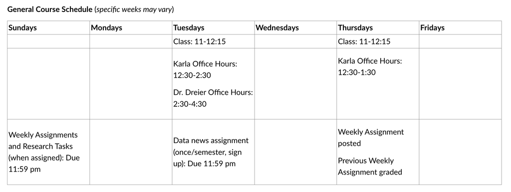

## Pause demo: inside a raw HTML div (needs `.fragment`)

This shows immediately — plain text inside a raw HTML div.

This pauses correctly, because it’s a real fragment div, not three dots.

## Pause demo: a whole list

- Point one
- Point two
- Point three

## Default: pause between bullets and lines

Unless a slide is meant to dump everything at once (e.g. a dense links/resources slide), **default to pausing between bullets and between separate lines/sentences** so the presenter reveals one idea at a time:

- **Bullet lists (`-`/`1.`):** wrap the whole list in `::: {.incremental}` so every item is its own click — this works even nested inside a raw HTML `<div>` (Pandoc still parses list markdown inside HTML blocks).
- **Separate lines/paragraphs that aren’t a list:** a plain `. . .` between them now works reliably (see “Pausing between lines or images” above) — including inside `::: {...}` fenced divs and `layout=` columns. The one place it still doesn’t work is inside a raw HTML `<div>...</div>` block; use `::: {.fragment}` there instead, and don’t share one fragment wrapper across multiple lines you want to reveal separately — each line needs its own `.fragment` (or its own `. . .` marker).
- A slide with just one short idea, or one meant to be read as a whole (links/resources, a single quote), doesn’t need this — use judgment.

## Basic text formatting

Regular text, **bold**, *italic*, and `inline code` — plain markdown, no HTML needed.

> A blockquote, for a quote or a callout note.
- A bullet
- Another bullet
  - A sub-bullet
1. A numbered item
2. Another numbered item

## Two columns

### Left side

Text or a list here.

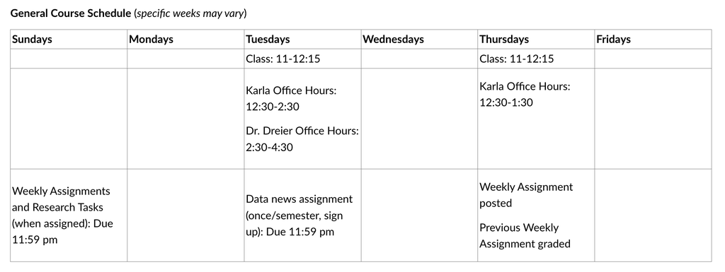

## Two-column layout via `layout=` (more control)

`.columns`/`.column` above is the simplest option. For exact proportional control (and to combine with images/captions/notes cleanly), use a `layout=` panel instead:

```
:::: {layout="[42,58]"}

::: {#first-column}
<div style="font-size: 0.9em; line-height: 1.3;">
Text column content here.
</div>
:::

::: {#second-column}
<div style="text-align: center;">
![](my_image.png){style="max-height: 40vh; width: auto;"}
</div>
:::

::::
```

The numbers are relative proportions (don’t need to sum to 100). **Put custom `style` on a nested `<div>` inside each column** — not on `#first-column`/`#second-column` itself — see the gotcha further down; Quarto silently discards it otherwise.

## Grid layout: multi-row panels & grouped pauses

For more than two columns, or extra full-width rows, use `.grid`/`.grid-item` instead of a `layout=` panel:

```
:::: {.grid layout="[1,2]"}
::: {.grid-item}
Text here.
:::
::: {.grid-item}
![](chart.png)
:::
::::

:::: {.grid}
::: {.grid-item span-col=2}
A full-width row below the two columns above.
:::
::::
```

`span-col=N` makes one grid item span N columns — handy for a full-width row under a multi-column row.

**Grouping multiple elements to reveal on the same click:** give each element the same `fragment-index`:

```
::: {.grid-item .fragment fragment-index=1 .fade-in}
Text that appears on click 1.
:::

::: {.grid-item .fragment fragment-index=1 .fade-in}
![](chart.png)
:::
```

Both fade in together on that first click; use `fragment-index=2` on the next group for a second, separate click.

## Dark background slide

Use `{background-color="#1a1a1a"}` on the slide heading (even an empty one) for a full-bleed dark slide, and set text color inline since the theme’s default text is dark:

```
## {background-color="#1a1a1a"}

<div style="color:#ffffff;">
Your content here.
</div>
```

This is what the dark slide looks like.

## Speaker notes

Text here shows on the slide.

# A section divider slide

A single `#` heading (instead of `##`) makes a full-bleed section-break slide — handy for splitting a lecture into parts. **Always put `{background-color="#2c3e50"}` on it** — that slate is the standard contrast color for these decks; the theme flips the heading text to light automatically.

## Gotcha: blockquotes nested under a bullet

If you want a note/blockquote to appear under a specific bullet (not as a new top-level block), you need a **blank line** before the `>` — otherwise Pandoc doesn’t parse it as a real blockquote and it renders as broken literal text.

```
- My bullet point

  > A properly nested note under that bullet.
```

## Gotcha: image paths

Always double-check the image path is relative to *this* file’s location, not to the folder in general. A quick `quarto render` will silently produce a blank spot (or a console warning) if the path is wrong — check the rendered `.html` if an image doesn’t show up.

## Linking an image

Wrap the `<img>` in a plain `<a>` tag:

```
<a href="https://example.com/" target="_blank">
<img src="my_image.png" style="width: 100%;" />
</a>
```

`target="_blank"` opens the link in a new tab, so clicking during a live presentation doesn’t lose the slide.

## Gotcha: `class="fragment"` directly on an `<img>` tag gets silently dropped

With `self-contained: true`, Quarto re-embeds every image as a base64 `data:` URI — and when it rebuilds the `<img>` tag to do that, it only keeps `src`/`alt`/`style`-type attributes and **drops a `class="fragment"` written directly on the tag**, with no warning. The image just never pauses.

```
<!-- Doesn't work — class gets stripped during self-contained image embedding -->
<img src="my_image.png" class="fragment" style="width: 100%;" />

<!-- Works — wrap it in a fragment div instead -->
::: {.fragment}
<img src="my_image.png" style="width: 100%;" />
:::
```

Same underlying lesson as the `layout=` panel gotcha above: **verify by grepping the rendered `.html`, not the `.qmd`** — since the image’s filename disappears into the base64 blob, search for the wrapping `class="fragment"` div instead of the image’s `src`.

## Gotcha: shrinking a dense slide

If a slide has too much content, add `{.smaller}` right after the heading text — no custom CSS class needed, it’s built into the theme:

```
## A dense slide {.smaller}
```

If that’s not enough (e.g. a `layout=` panel or raw HTML block `{.smaller}` doesn’t reach), see “Fitting content to the slide” below.

## Gotcha: `layout=` columns silently drop custom styles

`:::: {layout="[X,Y]"}` column panels are convenient, but Quarto **overwrites the `style` attribute** on `::: {#first-column style="..."}` / `#second-column` with its own auto-generated `flex-basis` rule — any custom `font-size`, `line-height`, `display: flex`, etc. placed directly on that column div is silently discarded at render time. There’s no warning; the `.qmd` looks correct and `quarto render` succeeds anyway.

**Fix:** put your styling on a nested `<div>` *inside* the column instead of on the column div itself:

```
::: {#first-column}
<div style="font-size: 0.9em; line-height: 1.3;">
Your content here.
</div>
:::
```

**Always verify a style change actually landed** — grep the rendered `.html` for it after `quarto render`; don’t just trust that editing the `.qmd` was enough.

## Fitting content to the slide (without going comically small)

**Base rule: if a slide’s text overflows the screen, set it to `font-size: 0.9em` first.** Apply it as `## Slide Title {style="font-size: 0.9em;"}` on the heading — that puts the `style` on the generated `<section>`, so it scales the whole slide with one clean mechanism. This is the default first move, not a last resort.

1. **0.9em via the heading `style=` attribute is step one.** Don’t reach for `{.smaller}` as the default fix — it’s a bigger, less predictable jump (the theme’s own preset reduction) than a controlled 0.9em.
2. **Never stack `{.smaller}` and an explicit `font-size` on the same slide.** They compound (e.g. `.smaller`’s own reduction × 0.9 again) and overshoot into unreadably tiny — this has actually happened. Pick one mechanism per slide.
3. **If 0.9em alone doesn’t clear the overflow**, then: check column proportions — a narrow `layout="[25,75]"` text column forces long bullets to wrap into many lines, and rebalancing (e.g. `[42,58]`) is often the real fix, not more shrinking.
4. **Cap images by `max-height` in `vh` units** (e.g. `style="max-height: 40vh; width: auto;"`), not just `width: 100%` — width-only sizing lets a tall image blow past the slide regardless of column width.
5. **Tighten margins/line-height before dropping font-size further.** Cutting `line-height` (to ~1.2–1.3) and list-item `margin-bottom` (to ~0.15–0.2em) often recovers enough room without going below 0.9em at all.
6. **Only drop below 0.9em if 1–5 didn’t create enough room**, and treat that as unusual — technically-not-overflowing-but-uncomfortably-tiny isn’t a fix.
7. **Default toward bigger, not smaller.** Once content fits, images and text should be as large as the slide comfortably allows — keep normal margins/column gaps rather than cramming just because there’s room to shrink more.
8. **Always render and check.** `quarto render`, then actually look at (or grep) the output — don’t assume a style change worked, especially inside a `layout=` column panel (see the gotcha above).

## Citing sources — always use `@key` citations, never hand-written links

**Every source citation on a slide uses a Quarto `@key` citation** keyed to an entry in `references_2140.bib`. Do **not** hand-write `<a href>` links or plain-text “(Author Year)” strings for sources — `@key` renders a clickable citation that jumps to the References slide, and citeproc formats the full APA entry there automatically.

- Parenthetical: `[@dignazio2020data]` → “(D’Ignazio & Klein, 2020)”
- Narrative: `@dignazio2020data` → “D’Ignazio & Klein (2020)”
- With a locator: `@silberzahn2018many [Fig. 2, p. 346]` → “Silberzahn et al. (2018, Fig. 2, p. 346)”
- As a source line under a figure: put it in a fenced div so citeproc processes it — `::: {style="font-size: 0.6em; color: #666;"}` / `Source: @silberzahn2018many [p. 345]` / `:::`. (A raw HTML `<div>` swallows the citation — use `:::`, not `<div>`.)

If the source isn’t in `references_2140.bib` yet, add a BibTeX entry for it there first.

## For [Day]:

**Every deck’s last three slides, in this order: next-class reading, TL;DR, References.** This slide is the first of those three — it names the *next* class meeting’s assigned reading, using the `## For [Day]:` heading style (matches the “For Thursday:” / “For Tuesday:” pattern already used elsewhere in this course’s decks). Pull the actual reading from the syllabus’s Course Schedule, verified against it, not invented:

[*Fundamentals*, Ch. X — see the full schedule on the syllabus](https://skdreier.github.io/POLS2140/)

## TL;DR

**Second-to-last slide.** Once the deck has real lecture content, replace this with 3–5 genuine main takeaways generated from *that lecture’s* actual material — not generic placeholders. Example shape:

- Point one — the single biggest idea from the lecture
- Point two — a key term/concept students should walk away knowing
- Point three — how this connects to the next class or an assignment
- (Point four/five if the lecture genuinely covered that much ground — don’t pad to hit 5)

## References

**Every deck ends with this slide, even with nothing yet cited.** Without a `bibliography:` set, or without this `::: {#refs}` placeholder, Quarto tacks the reference list onto whatever the last content slide is and it overflows. The `## References` heading only renders if nothing (e.g. an HTML comment block) sits between it and the `::: {#refs}` div, and if `biblio-title:` is NOT set in the YAML.